# Chapter 06 Problem Set Key

### 6.3

Using the basic form of the Lotka–Volterra equations (3a and 3b), replace the exponential part of the “victim” equation with the logistic equation and solve for the equilibrium state, expressing the critical value of $P$ as a function of $V$. Plot the isocline.

No additional comments aside from (1) you know how to do the algebra and (2) you know how to plot $f(x)$ against $x$.

> $$\begin{aligned}
> \frac{dV}{dt} &= rV - aPV\\
> \frac{dP}{dt} &= bVP - mP
> \end{aligned}$$
> For eqn. 1:
> $$\begin{aligned}
> &0 = rV\left(\frac{K - V}{K}\right) - aPV \\
> &0 = V(r\left(\frac{K - V}{K}\right) - aP) \\
> &\text{The first equilibrium is } V^* = 0 \\
> &\text{Setting } r\left(\frac{K - V}{K}\right) - aP \text{ to 0 will
> also be an equilibirum} \\
> &0 = r\left(\frac{K - V}{K}\right) - aP \\
> & aP = r\left(\frac{K - V}{K}\right) \\
> &\text{The second equilibrium is }P^* = \frac{r}{a}\left(\frac{K -
> V}{K}\right)
> \end{aligned}$$

> Label the isoclines for the first equation.

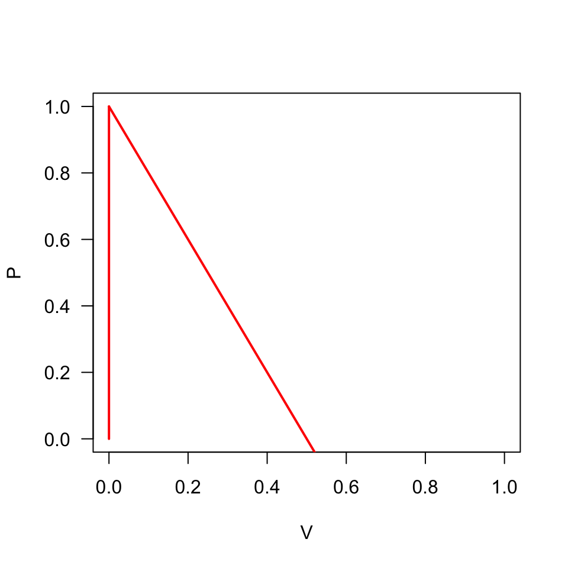

> ```r
> r <- 0.2
> K <- 0.5
> a <- 0.2
> V <- seq(from = 0, to = 1, by = 0.01)
>
> isocline_2 <- r/a*((K - V) / K)
>
> plot(x = NA, type = "n", xlim = c(0, 1), ylim = c(0, 1), las = 1, xlab = "V", ylab = "P")
> segments(x0 = 0, x1 = 0, y0 = 0, y1 = 1, lwd = 2, col = "red")
> lines(x = V, y = isocline_2, lwd = 2, col = "red")
> ```

### 6.4

Using the basic form of the Lotka–Volterra equations (3a and 3b), replace the exponential part of the predator equation with the logistic equation and solve for the equilibrium state, expressing the critical value of P as a function of $V$. Plot the isoclines.

No additional comments aside from (1) you know how to do the algebra and (2) you know how to plot $f(x)$ against $x$.

> $$\begin{aligned}
> \frac{dV}{dt} &= rV - aPV\\
> \frac{dP}{dt} &= rPV\left(\frac{K - P}{K}\right) - mP
> \end{aligned}$$

> For eqn. 2:
> $$\begin{aligned}
> &0 = rPV\left(\frac{K - P}{K}\right) - mP \\
> &0 = P(rV\left(\frac{K - P}{K}\right) - m) \\
> &\text{The first equilibrium is } P^* = 0 \\
> &\text{Setting } rV\left(\frac{K - P}{K}\right) - m \text{ to 0 will
> also be an equilibirum} \\
> &0 = rV\left(\frac{K - P}{K}\right) - m \\
> &0 = rV - \left(\frac{rVP}{K}\right) - m \\
> &\frac{rVP}{K} = rV - m \\
> &P = \frac{K\left(rV - m\right)}{rV} \\
> &\text{The second equilibrium is }P^* = K - \frac{Km}{rV}
> \end{aligned}$$

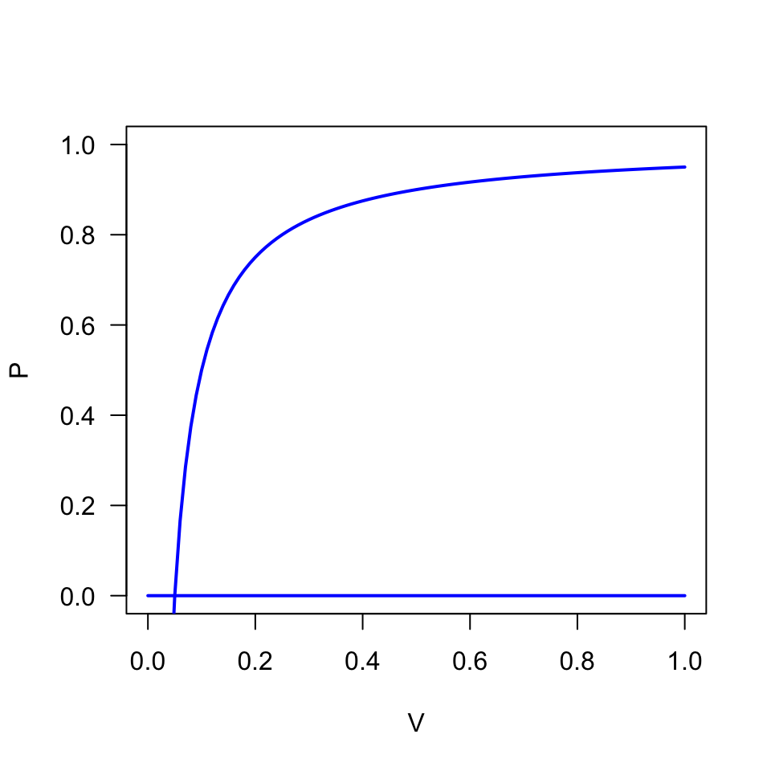

> ```r
> r <- 0.2
> K <- 1
> m <- 0.01
> V <- seq(from = 0, to = 1, by = 0.01)
>
> isocline_2 <- K - K*m/(r*V)
>
> plot(x = NA, type = "n", xlim = c(0, 1), ylim = c(0, 1), las = 1, xlab = "V", ylab = "P")
> segments(x0 = 0, x1 = 1, y0 = 0, y1 = 0, lwd = 2, col = "blue")
> lines(x = V, y = isocline_2, lwd = 2, col = "blue")
> ```

### 6.7

Carnivorous tunicates are sessile, so they must wait for their food to come their way. How many food items will a tunicate eat in a given period of time? Suppose that the overall time they allot to eating during the day is 12 hours (tunicates sleep the rest of the time), and each time a food item is taken in, an individual tunicate requires half an hour to swallow it. The frequency at which food items come its way will depend on the density of those food items. The time required to encounter a food item will be inversely related to the density of the food items, or $1/V$. What is the equation that relates the total number of food items eaten in a day to the population density of the food? Make a graph of the equation for values of $V$ from 0 to 30.

It takes 0.5 hr. to process/handle the food item, it will take $1/V$ hr. encounter a food item, and there will be a total of
$$\frac{12}{0.5 +
\frac{1}{V}}$$
in a 12-hr. period. This can be rewritten, after multiplying the numerator and denominator by $V$, as
$$\frac{12V}{1 + 0.5V}$$
Please just make the graph.

> It takes 0.5 hr. to process/handle the food item, it will take $1/V$ hr. encounter a food item, and there will be a total of
> $$\frac{12}{0.5 +
> \frac{1}{V}}$$
> in a 12-hr. period. This can be rewritten as
> $$\frac{12V}{1 + 0.5V}$$
> This can be graphed:

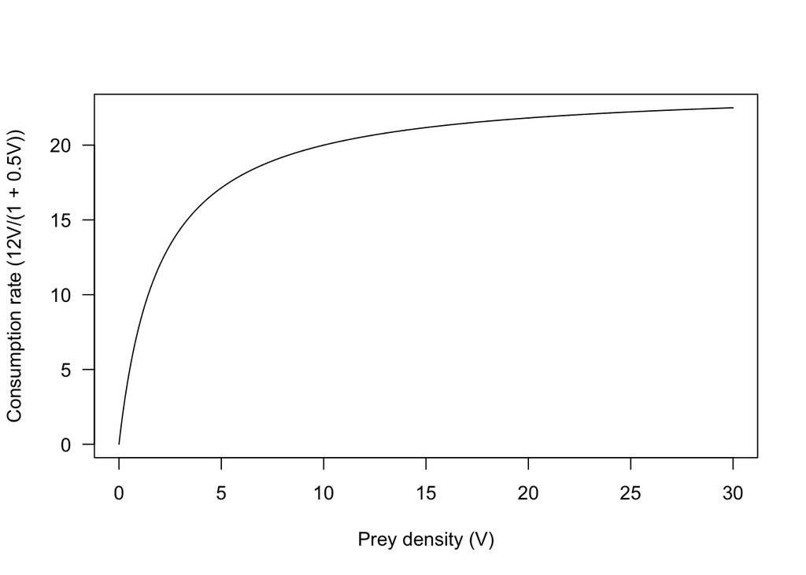

> ```r
> V <- seq(from = 0, to = 30, by = 0.01)
> fV <- 12*V / (1 + 0.5*V)
>
> plot(x = V, y = fV, xlab = "Prey density (V)", ylab = "Consumption rate (12V/(1 + 0.5V))", las = 1, type = "l")
> ```

### 6.10

Plot the type II functional response for $c = 100$ and $g = 100$, $300$, and $1,000$.

No additional comments.

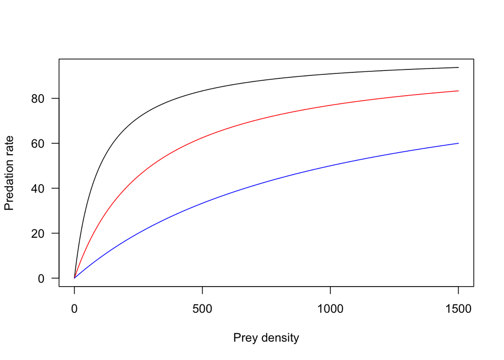

> ```r
> V <- seq(from = 0, to = 1500, by = 1)
> FR <- function(c = 100, g, x = V) {
>   c*x/(g + x)
> }
>
> g100 <- FR(g = 100)
> g300 <- FR(g = 300)
> g1500 <- FR(g = 1000)
>
> plot(x = V, y = g100, type = "l", las = 1, xlab = "Prey density", ylab = "Predation rate")
> lines(x = V, y = g300, col = "red")
> lines(x = V, y = g1500, col = "blue")
> ```

### 6.12

Combine the prey equation that includes density dependence (equation 6a) with the idea of a type II functional response. Write the differential equation, and solve for the isocline.

No additional comments.

> The differential equation:
> $$\frac{\mathrm{dV}}{\mathrm{d}t} = rV\left(\frac{K - V}{K}\right) -
> \frac{cVP}{g + V}$$

> The isocline:

> $$\begin{aligned}
> \frac{\mathrm{dV}}{\mathrm{d}t} &= rV\left(\frac{K - V}{K}\right) -
> \frac{cVP}{g + V} \\
> 0 &= rV\left(\frac{K - V}{K}\right) - \frac{cVP}{g + V} \\
> 0 &= V\left(r\left(\frac{K - V}{K}\right) - \frac{cP}{g + V}\right)
> \\
> V^* &= 0\text{ is onen isocline}\\
> 0 &= r\left(\frac{K - V}{K}\right) - \frac{cP}{g + V} \\
> \frac{cP}{g + V} &= r\left(\frac{K - V}{K}\right) \\
> cP{g + V} &= r\left(\frac{K - V}{K}\right)(g + V) \\
> P^* &= r\left(\frac{K - V}{K}\right)(g + V)c^{-1} \\
> &\text{Above is fine, but I am going to rewrite it with each term
> being $V^{n}$}\\
> P^* &= -\left(\frac{r}{Kc}\right)V^2 + \left(\frac{r(K -
> g)}{Kc}\right)V + \frac{gr}{c}
> \end{aligned}$$

### 6.13

Using the equation derived in exercise 6.12, make a graph of $P$ versus $V$ for the following four parameter sets: $r = 5$, $c = 50$, $K = 100$, $g = 25$; $r = 5$, $c = 50$, $K = 120$, $g = 25$; $r = 5$, $c = 50$, $K = 100$, $g = 50$; and $r = 5$, $c = 50$, $K = 80$, $g = 25$.

No additional comments.

> $$P^* = -\left(\frac{r}{Kc}\right)V^2 +
> \left(\frac{r(K - g)}{Kc}\right)V + \frac{gr}{c}$$

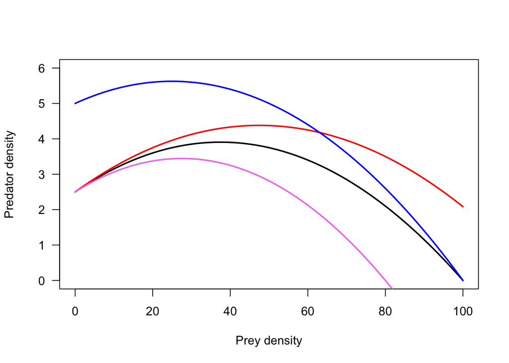

> ```r
> prey.dens <- seq(from = 0, to = 100, by = 0.1)
>
> prey.iso <- function(r, c, K, g, V) {
>   PStar <- -r*V*V/(K*c) + (r*(K - g)/(K*c))*V + g*r/c
>   return(PStar)
> }
>
> r <- 5
> c <- 50
> K1 <- 100
> K2 <- 120
> K3 <- 100
> K4 <- 80
> g1 <- 25
> g2 <- 25
> g3 <- 50
> g4 <- 25 # in the answers it's 50
>
> prey.iso1 <- prey.iso(r = r, c = c, K = K1, g = g1, V = prey.dens)
> prey.iso2 <- prey.iso(r = r, c = c, K = K2, g = g2, V = prey.dens)
> prey.iso3 <- prey.iso(r = r, c = c, K = K3, g = g3, V = prey.dens)
> prey.iso4 <- prey.iso(r = r, c = c, K = K4, g = g4, V = prey.dens)
>
> plot(x = prey.dens, y = prey.iso1, las = 1, xlab = "Prey density", ylab = "Predator density", type = "l", lwd = 2, ylim = c(0, 6))
>   lines(x = prey.dens, y = prey.iso2, lwd = 2, col = "red")
>   lines(x = prey.dens, y = prey.iso3, lwd = 2, col = "blue")
>   lines(x = prey.dens, y = prey.iso4, lwd = 2, col = "violet")
> ```